# PLATEAU INSURANCE REPORT ANALYSIS

# MULTIVARIATE ANALYSIS

```python
#using a pairplot to explore the relationship between the nummerical features in the dataset

df=Data[['age','bmi','children','charges']].head(25)
df
```

|  | age | bmi | children | charges |
| --- | --- | --- | --- | --- |
| 0 | 21 | 16.000 | 1 | 3167.45585 |
| 1 | 18 | 33.770 | 1 | 1725.55230 |
| 2 | 28 | 33.000 | 3 | 4449.46200 |
| 3 | 33 | 22.705 | 0 | 21984.47061 |
| 4 | 32 | 28.880 | 0 | 3866.85520 |
| 5 | 26 | 15.500 | 2 | 14455.64405 |
| 6 | 37 | 16.500 | 2 | 6877.98010 |
| 7 | 28 | 17.290 | 0 | 3732.62510 |
| 8 | 37 | 29.830 | 2 | 6406.41070 |
| 9 | 21 | 17.400 | 1 | 2585.26900 |
| 10 | 25 | 26.220 | 0 | 2721.32080 |
| 11 | 32 | 14.000 | 2 | 32734.18630 |
| 12 | 23 | 34.400 | 0 | 1826.84300 |
| 13 | 19 | 17.800 | 0 | 1727.78500 |
| 14 | 27 | 42.130 | 0 | 39611.75770 |
| 15 | 19 | 24.600 | 1 | 1837.23700 |
| 16 | 27 | 15.000 | 2 | 15006.57945 |
| 17 | 23 | 23.845 | 0 | 2395.17155 |
| 18 | 56 | 40.300 | 0 | 10602.38500 |
| 19 | 30 | 35.300 | 0 | 36837.46700 |
| 20 | 51 | 17.050 | 0 | 9644.25250 |
| 21 | 39 | 18.300 | 5 | 19023.26000 |
| 22 | 18 | 34.100 | 0 | 1137.01100 |
| 23 | 60 | 16.000 | 0 | 13204.28565 |
| 24 | 37 | 28.025 | 2 | 6203.90175 |

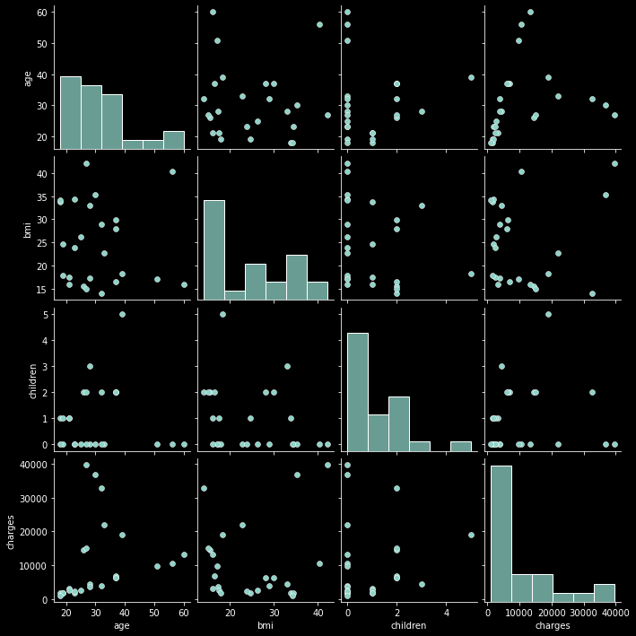

```python
plt.style.use('dark_background')
sns.pairplot(df)
```

```
[Text(0.5, 1.0, 'Data Correlations')]
```

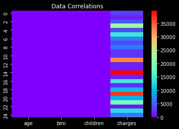

```python
## Heatmeap showing the correlation between features.
sns.heatmap(df.head(30), cmap='rainbow').set(title='Data Correlations')
```

OBSERVATIONS

1.From the multivariate analysis of all numerical values, it can be observed that 0 number of children(meaning those without children) are heavily affected in all features.

```python
Data.tail()
```

|  | age | sex | bmi | children | smoker | region | charges |
| --- | --- | --- | --- | --- | --- | --- | --- |
| 1333 | 50 | male | 30.97 | 3 | no | northwest | 10600.54830 |
| 1334 | 52 | female | 46.75 | 5 | no | southeast | 12592.53450 |
| 1335 | 54 | female | 47.41 | 0 | yes | southeast | 63770.42801 |
| 1336 | 37 | female | 47.60 | 2 | yes | southwest | 46113.51100 |
| 1337 | 46 | female | 48.07 | 2 | no | northeast | 9432.92530 |

```python
#Table showing ratio of smokers to non smokers

Smokers = Data[['age', 'smoker', 'sex']]
Smokers
```

|  | age | smoker | sex |
| --- | --- | --- | --- |
| 0 | 21 | no | female |
| 1 | 18 | no | male |
| 2 | 28 | no | male |
| 3 | 33 | no | male |
| 4 | 32 | no | male |
| ... | ... | ... | ... |
| 1333 | 50 | no | male |
| 1334 | 52 | no | female |
| 1335 | 54 | yes | female |
| 1336 | 37 | yes | female |
| 1337 | 46 | no | female |

1338 rows × 3 columns

```python
Smokers['smoker'].value_counts('no','yes')
```

```
no     0.795217
yes    0.204783
Name: smoker, dtype: float64
```

From the above data ratio of smokers shown, its obvious non smokers are more than the smokers in Plateau community. Below is a visualization showing the graphical description of the values.

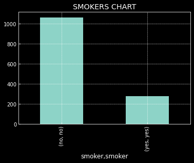

```python
#Ratio of smokers(yes) to Non smokers(no)
plt.style.use('dark_background')

Data.groupby('smoker')['smoker'].value_counts().plot.bar(title='SMOKERS CHART')
```

```python
#Table showing BMI of Females to Males

Data[['bmi', 'sex']].head(20)
```

|  | bmi | sex |
| --- | --- | --- |
| 0 | 16.000 | female |
| 1 | 33.770 | male |
| 2 | 33.000 | male |
| 3 | 22.705 | male |
| 4 | 28.880 | male |
| 5 | 15.500 | female |
| 6 | 16.500 | female |
| 7 | 17.290 | female |
| 8 | 29.830 | male |
| 9 | 17.400 | female |
| 10 | 26.220 | male |
| 11 | 14.000 | female |
| 12 | 34.400 | male |
| 13 | 17.800 | female |
| 14 | 42.130 | male |
| 15 | 24.600 | male |
| 16 | 15.000 | female |
| 17 | 23.845 | male |
| 18 | 40.300 | male |
| 19 | 35.300 | male |

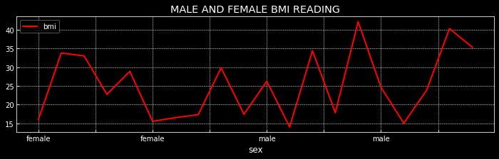

```python
#Visualization showing the difference in Female BMI to Male BMI.

Data[['bmi', 'sex']].head(20).plot(x='sex', y='bmi', color='red', figsize=(12,3), title='MALE AND FEMALE BMI READING')
```

```python
Data['sex'].value_counts('male', 'female')
```

```
male      0.505232
female    0.494768
Name: sex, dtype: float64
```

```python
#Male BMI
Data.loc[Data['sex']=='male'].value_counts('bmi')
```

```
bmi
32.300    8
30.875    7
34.100    6
25.460    6
24.320    5
         ..
29.300    1
29.355    1
29.370    1
29.400    1
53.130    1
Length: 391, dtype: int64
```

```python
#Female BMI
Data.loc[Data['sex']=='female'].value_counts('bmi')
```

```
bmi
29.920    6
26.600    5
30.495    5
23.180    5
32.300    5
         ..
29.370    1
29.500    1
29.545    1
29.640    1
50.900    1
Length: 403, dtype: int64
```

```python
#Smoking habit of Customers base on regions
habit= pd.crosstab(Data.region,Data.smoker)
habit
```

| smoker region | no | yes |
| --- | --- | --- |
| northeast | 257 | 67 |
| northwest | 267 | 58 |
| southeast | 273 | 91 |
| southwest | 267 | 58 |

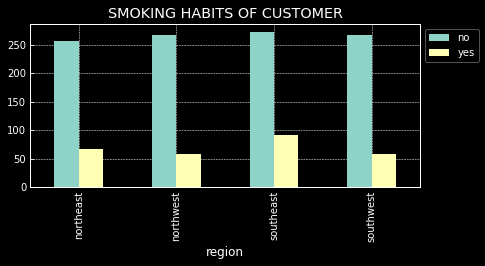

```python
plt.style.use('dark_background')
habit.plot.bar(title='SMOKING HABITS OF CUSTOMER',figsize=(7,3)).legend(loc='upper left', bbox_to_anchor=(1.0,1))
```

```python
mean = Data[['bmi', 'sex', 'children']]
mean
```

|  | bmi | sex | children |
| --- | --- | --- | --- |
| 0 | 16.000 | female | 1 |
| 1 | 33.770 | male | 1 |
| 2 | 33.000 | male | 3 |
| 3 | 22.705 | male | 0 |
| 4 | 28.880 | male | 0 |
| ... | ... | ... | ... |
| 1333 | 30.970 | male | 3 |
| 1334 | 46.750 | female | 5 |
| 1335 | 47.410 | female | 0 |
| 1336 | 47.600 | female | 2 |
| 1337 | 48.070 | female | 2 |

1338 rows × 3 columns

```python
mean.describe()
```

|  | bmi | children |
| --- | --- | --- |
| count | 1338.000000 | 1338.000000 |
| mean | 30.682687 | 1.094918 |
| std | 6.145674 | 1.205493 |
| min | 14.000000 | 0.000000 |
| 25% | 26.315000 | 0.000000 |
| 50% | 30.400000 | 1.000000 |
| 75% | 34.700000 | 2.000000 |
| max | 53.130000 | 5.000000 |

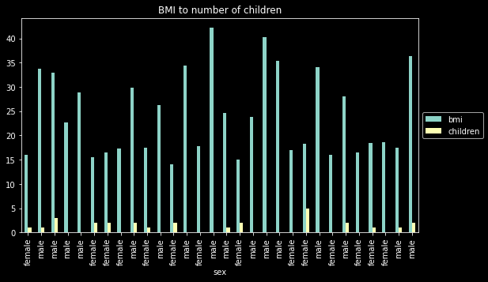

```python
#Chart showing sex and the BMI to number of children

Data.head(30).plot.bar(x='sex', y=['bmi', 'children'], figsize=(9,5), title='BMI to number of children').legend(loc='center left', bbox_to_anchor=(1, 0.5,))
```

```python
Data[['sex','bmi','children']].head(21).loc[(Data['sex'] == 'female')]
```

|  | sex | bmi | children |
| --- | --- | --- | --- |
| 0 | female | 16.00 | 1 |
| 5 | female | 15.50 | 2 |
| 6 | female | 16.50 | 2 |
| 7 | female | 17.29 | 0 |
| 9 | female | 17.40 | 1 |
| 11 | female | 14.00 | 2 |
| 13 | female | 17.80 | 0 |
| 16 | female | 15.00 | 2 |
| 20 | female | 17.05 | 0 |

It's observed from the above table that the mean bmi of women and there number of children ain't thesame as it varies i.e those with same 1 children, 2 children or 0 children have different bmi readings.

```python
Data[['bmi']].mean()
```

```
bmi    30.682687
dtype: float64
```

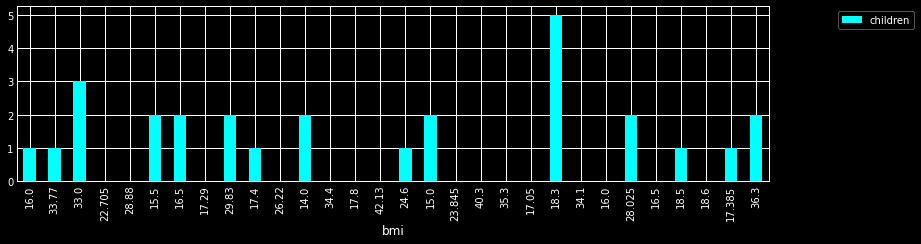

```python
#BMI to Children reading

plt.style.use('dark_background')

Data.head(30).plot.bar(x='bmi', y='children', figsize=(12,3), color='cyan').legend(loc='upper right',bbox_to_anchor=(1.2,1))
```

A report analysis compiled by Paul S. Umaru from Code Plateau 4.0.